# Course overview

Author

Affiliation

Dave Clark

Binghamton University

Published

January 8, 2025

# About this class

## All models are wrong $\ldots$

“All models are wrong, some are useful.” Box & Draper (1987)

This course is based on the principle that to build useful models, we need:

- an intuitive understanding of regression models
- data science skills
- careful and creative thinking about politics
- a general skepticism of individual models, but an optimism about the modeling enterprise

## The regression model

This course focuses on the linear regression model, but with a heavy emphasis on data science skills like data management/wrangling, and coding.

## Course Goals

In May, you should be able to:

- develop and test hypotheses about politics.
- estimate, evaluate, and interpret basic linear and nonlinear regression models.
- evaluate, understand, clean, wrangle, join, and reshape data.
- write R code, to manage data, implement simulation methods, estimate models, visualize data/predictions.
- understand the data generation process as a motivation for modeling.

## This class

Is not a math class,

[figure not shown]

but one that uses basic math toward an applied goal.

## This class

- is aimed at application; the more you struggle with code, the more you’ll learn.
- the more you **use** other people’s code, the less you’ll learn.
- the more you **look** at other people’s code, the more you’ll learn. You should live on [stackoverflow](https://stackoverflow.com/) etc.
- is applied - if you apply the tools we cover, you’ll learn a lot; if not, you won’t.
- the students who do best later on in this program challenge themselves here.

## This class

- is a collaborative effort among you, and with me and Oguzhan. We learn from each other when we collaborate.
- This means having honest conversations in class about what we do and do not understand.
- It means working together to learn R, to wrangle data, and to understand models; working together on your assignments.
- the most successful cohorts are those that work collaboratively; this does not mean free-riding, but struggling with everything together.

## What do you need to know for 501?

What do you need at the start?

- [basic R](https://datacarpentry.org/r-socialsci/index.html) or this [terrific bookdown book](https://bookdown.org/yih_huynh/Guide-to-R-Book/) written by a graduate student for graduate students.
- basic probability theory
- basic matrix algebra

## Matrix algebra

You should be able to make sense of this in terms of dimensions and operations:

$$\beta = (X'X)^{-1} X'y$$
where $X$ is a data matrix of rows and columns; these are the variables in a regression. $y$ is the outcome variable, the same number of rows as $X$. Define the dimensions of $X$, $y$, and $\beta$, of $(X'X)^-1$ and $X'y$.

## Probability theory

- what are probability distributions?
- what is the PDF of a variable?
- what is the CDF of a variable?

## Understanding Regression models

The class focuses on regression models of the general form (scalar notation):

$$y_i = \beta_0 + X_1\beta_1 + X_2\beta_2 \ldots + X_k\beta_k + \epsilon$$

or in matrix notation,

$$\mathbf{y} = \mathbf{X} \mathbf{\beta} + \mathbf{\epsilon}$$

An outcome, $y$ is a function of some combination of $X$ variables, their coefficients ($\beta$, including an intercept), and an error term.

## Regression models

Posit a statistical relationship between:

- an outcome variable, $y$.
- a covariate of interest, $x$.
- a set of controls, $\mathbf{X}$.

The effect of $x$ is denoted $\beta$. It is the *partial* effect of x on y, because removed from that effect are the effects of x -> X -> y. This is what we mean by *controlling for the effects of X*. Much more on this later.

## Regression models

Can be estimated using different technologies including:

- Least Squares
- Maximum Likelihood
- Bayesian methods

This course is about the technology of least squares; we will deal with one ML regression model (logit) later in the semester.

# Illustration

## Models to understand politics

$~$

This a methods class, but the methods are only meaningful to us insofar as they help us understand politics. So let’s motivate the class with a question about politics.

## Careful thinking

Correlation does not imply causation.

[figure not shown]

### Repression during the COVID-19 Pandemic

Among the products of the pandemic is an opportunity for governments, under the guise of protecting public health, to repress citizens.

There is some evidence of democratic backsliding prior to the pandemic, but the global public health crisis gave governments a specific and universal opportunity to take advantage of this softened ground and to become more authoritarian.

We’re going to examine the covariates of violence against civilians during the COVID period, focusing on how states of emergency create changes in government violence.

### Data

Let’s look at ACLED event data, and data on states of emergency during the COVID period from Lundgren et al (2020).

The next figure plots protests and repression since mid-2019, the onset of the pandemic marked at March 15, 2020.

The blue lines are local regressions showing trends; while protests return to pre-pandemic levels (similar to the years prior), repression increases since the onset of COVID-19.

### Protests

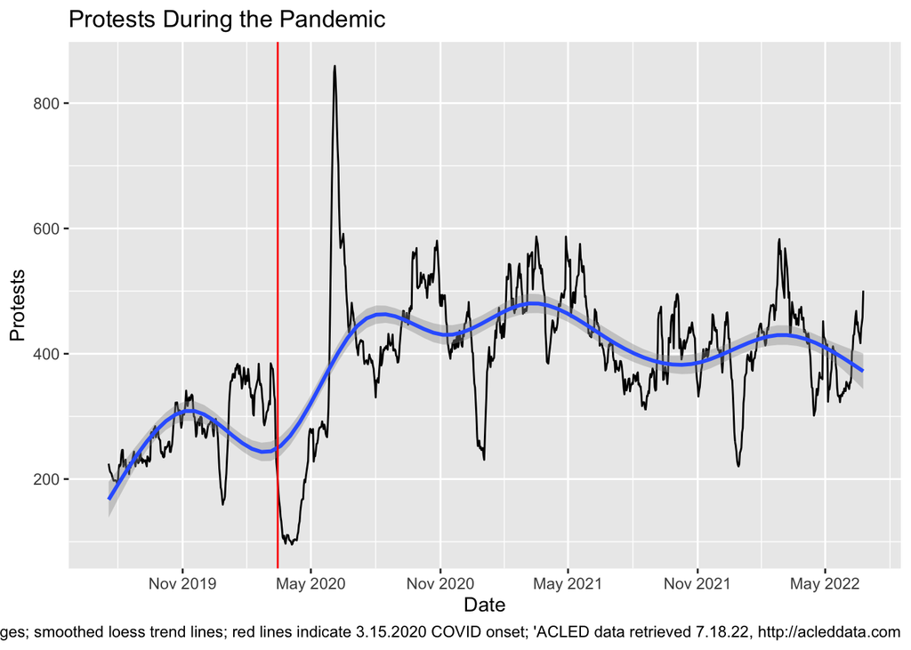

```r
acled<-read.csv("/Users/dave/Documents/2013/PITF/analysis/protests2021/data/2022analysis/acled2022.csv")

##Event_date variable has a "Chr" format.
#Need to convert it into date format to calculate 7 day averages for Protests and Violence against Civilians

acled$event_date<-as.Date(acled$event_date,format="%d %B %Y")
#class(acled$event_date)

##Compute number of events per day

acled$perday<-1

protests<-filter(acled,event_type=="Protests" )
stateviol<-filter(acled, event_type=="Violence against civilians")
protests<-aggregate(perday ~ event_date, data = protests, sum)
stateviol<-aggregate(perday ~ event_date, data = stateviol, sum)


##Calculating a 7 day moving average
protests$rollmean<-rollmean(protests$perday,k=7, fill=NA)
stateviol$rollmean<-rollmean(stateviol$perday,k=7, fill=NA)

protests <- protests %>% filter(protests$event_date < "2022-06-25")
stateviol <- stateviol %>% filter(stateviol$event_date < "2022-06-25")

protestplot <- ggplot(data=protests, aes(x=event_date, y=rollmean)) +
  geom_line()+
  geom_smooth() +
  geom_vline(xintercept=as.numeric(as.Date("2020-03-15")), color="red") +
  scale_x_date(date_breaks = "6 months", date_labels = '%b %Y')  +
  labs(x="Date", y="Protests", caption="7 day rolling averages; smoothed loess trend lines; red lines indicate 3.15.2020 COVID onset; 'ACLED data retrieved 7.18.22, http://acleddata.com") +
  ggtitle("Protests During the Pandemic")


protestplot
```

### Repression

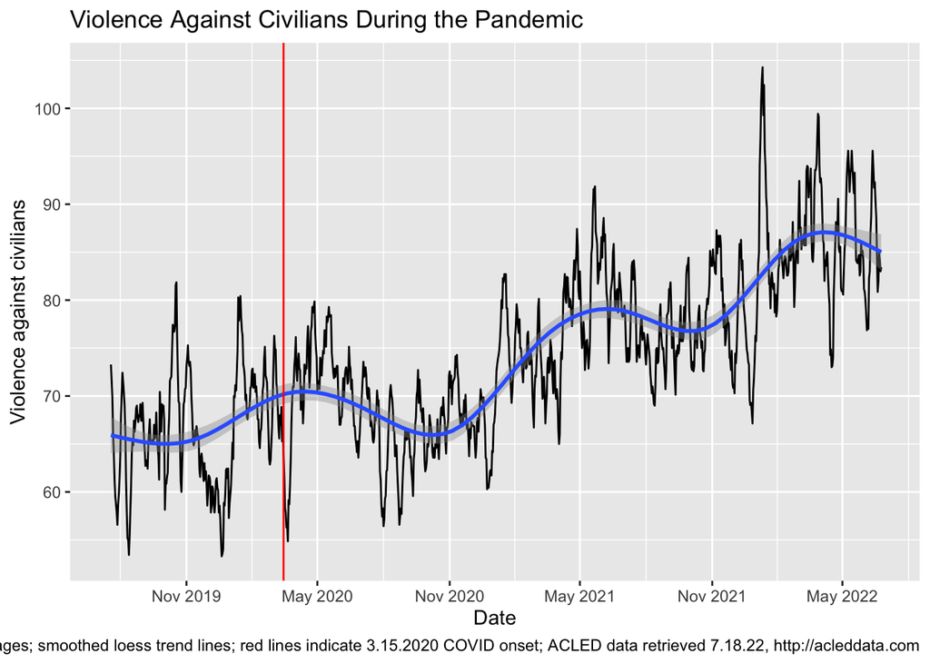

```r
repressionplot <- ggplot(data=stateviol, aes(x=event_date, y=rollmean)) +
  geom_line()+
  geom_smooth() +
  geom_vline(xintercept=as.numeric(as.Date("2020-03-15")), color="red") +
  scale_x_date(date_breaks = "6 months", date_labels = '%b %Y')  +
  labs(x="Date", y="Violence against civilians", caption="7 day rolling averages; smoothed loess trend lines; red lines indicate 3.15.2020 COVID onset; ACLED data retrieved 7.18.22, http://acleddata.com") +
  ggtitle("Violence Against Civilians During the Pandemic")

repressionplot
```

### States of Emergency during the Pandemic

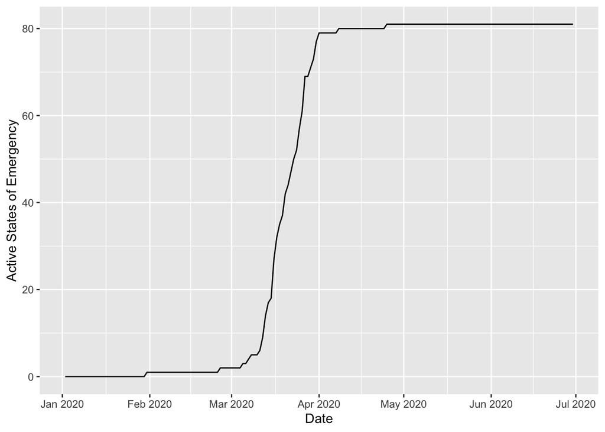

```r
####################
#analysis data
####################

#make analysis data frame
analysisdata <- left_join(perday, soe, by=c("ccode"="ccode", "event_date"="event_date"))
analysisdata <- left_join(analysisdata, covid, by=c("ccode"="ccode", "event_date"="date"))

#zeros for NA in soe_s
analysisdata <- analysisdata %>% mutate(across(soe_s, ~replace_na(., 0)))

#fill soe series after onset
analysisdata <- analysisdata %>% group_by(ccode) %>% mutate(cumSOE = cumsum(soe_s)) %>% ungroup

#plot cumulative states of emergency over time
totalsoe <- analysisdata %>% group_by(event_date) %>%
  summarise(across(cumSOE, sum)) %>%
  ungroup()

totalsoe$event_date <- as.Date(totalsoe$event_date)

totalsoe <- totalsoe %>% filter(event_date >"2020-01-01"& event_date <"2020-07-01")

ggplot() +
  geom_line(data=totalsoe, aes(x=event_date, y=cumSOE))+
  scale_x_date(date_breaks = "1 months", date_labels = '%b %Y') +
  labs ( colour = NULL, x = "Date", y =  "Active States of Emergency" )
```

### Modeling repression

Let’s build a simple model predicting violence against civilians. The data here are daily, covering 167 countries between January 2020 and July 2022. We’ll predict the 7 day moving average of repression depending on whether a state of emergency is in place.

$~$

My expectation is states of emergency will make repression easier to motivate and therefore, more frequent.

### The model

$y$ = violence against civilians

$x$ = states of emergency

Controlling for:

- new daily deaths from COVID (logged)
- percentage of the population over 65 years old
- the Human Development Index
- the 7 day average number of protests.

### Modeling Repression and SoEs

```r
##################
#models
#################

analysisdata$soeprotests <- analysisdata$cumSOE*analysisdata$protest7day
analysisdata$lnd =  log(analysisdata$new_deaths+.01)
#label variables for coef plot
library("labelled")
analysisdata <- analysisdata %>%
  set_variable_labels(
    cumSOE = "State of Emergency",
    lnd = "ln(New COVID deaths)",
    aged_65_older = "% age 65 +",
    human_development_index = "Human Development Index",
    protest7day = "Protests, 7 day avg",
    soeprotests = "SoE * Protests, 7 day avg",
    `Violence against civilians` = "Violence against Civilians"
  )

#model predicting repression during covid

m1 <- lm(data=analysisdata, `Violence against civilians` ~ cumSOE  + lnd + aged_65_older+human_development_index + protest7day )
#summary(m1)

library(sjPlot)
tab_model(m1, show.se=TRUE,  p.style="stars", show.ci=FALSE)
```

|  | Violence against Civilians |  |
| --- | --- | --- |
| Predictors | Estimates | std. Error |
| (Intercept) | 0.93 *** | 0.03 |
| State of Emergency | 0.26 *** | 0.01 |
| ln(New COVID deaths) | 0.02 *** | 0.00 |
| %age 65+ | -0.02 *** | 0.00 |
| Human Development Index | -0.68 *** | 0.04 |
| Protests,7 day avg | 0.04 *** | 0.00 |
| Observations | 165211 |  |
| R<sup>2</sup> / R<sup>2</sup> adjusted | 0.057 / 0.057 |  |
| * p<0.05 ** p<0.01 *** p<0.001 |  |  |

### Another look

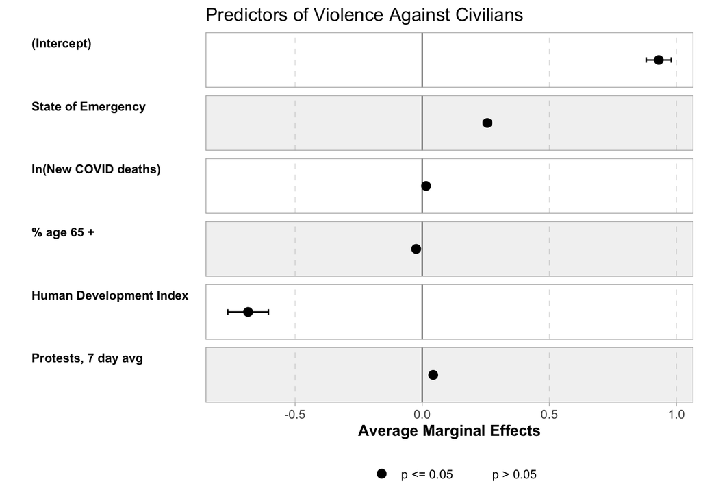

```r
#coefficient plot
ggcoef_model(
  m1,show_p_values = FALSE,
  signif_stars = FALSE, exponentiate =FALSE, intercept=TRUE,
  colour=NULL, include = c("cumSOE", "lnd", "aged_65_older", "human_development_index", "protest7day")
)+
  xlab("Average Marginal Effects") +
  ggtitle("Predictors of Violence Against Civilians")
```

### Quantities of interest (simulation)

Let’s generate predictions from the model by simulating the distribution of $\widehat{\beta}$:

- sample 1000 times from a multivariate normal distribution with mean $\widehat{\beta}$s and variances of $var(\widehat{\beta})$.
- plug those simulated $\widehat{\beta}$s into the equation using mean/median/mode values for the $X$s.

### Simulating quantities

First, set $SoE = 0$; vary $covid~deaths = ln(1 \ldots 28000)$, $\%~age~ 65 = 6$ (the median), $HDI = .74$ (the median), and $protests = 2$ (the median).

$$\widehat{y} = \beta_0 + \beta_1* 0 +\beta_2*log(p) + \beta_3*6 +\beta_4*.74+ \beta_5*2$$

then, repeat but with $SoE = 1$:

$$\widehat{y} = \beta_0 + \beta_1*1 +\beta_2*log(p) + \beta_3*6 +\beta_4*.74+ \beta_5*2$$

### Predicted Violence against Civilians

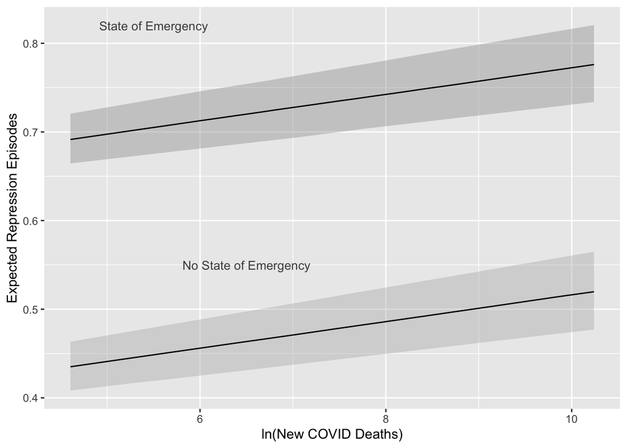

```r
#simulated quantities
sigma <- vcov(m1)
B <- data.frame(rmvnorm(n=1000, mean=coef(m1), vcov(m1)))

colnames(B) <-c('b0', 'b1', 'b2', 'b3', 'b4', 'b5')

predictions <- data.frame ( lb0 = numeric(0),med0= numeric(0),
      ub0= numeric(0),lb1= numeric(0),med1= numeric(0),ub1=
      numeric(0), deaths = numeric(0))

for (p in seq(0,28000,100)) {

  xbRA0  <- quantile(B$b0 + B$b1*0 + B$b2*log(p) + B$b3*6 +B$b4*.74+
                       B$b5*2, probs=c(.025,.5,.975))
  xbRA1 <- quantile(B$b0 + B$b1*1 + B$b2*log(p) + B$b3*6 +B$b4*.74+
                      B$b5*2, probs=c(.025,.5,.975))
  xbRA0<- data.frame(t(xbRA0))
  xbRA1<- data.frame(t(xbRA1))
  predictions[p:p,] <- data.frame(xbRA0, xbRA1, p)
}
predictions$deaths <- log(predictions$deaths)

#plot
ggplot()+
  geom_ribbon(data=predictions, aes(x=deaths, ymin=lb0, ymax=ub0),fill = "grey70", alpha = .4, ) +
  geom_ribbon(data=predictions, aes(x=deaths, ymin=lb1, ymax=ub1), fill= "grey60",  alpha = .4, ) +
  geom_line(data= predictions, aes(x=deaths, y=med0))+
  geom_line(data= predictions, aes(x=deaths, y=med1))+
  labs ( colour = NULL, x = "ln(New COVID Deaths)", y =  "Expected Repression Episodes" ) +
  annotate("text", x = 5.5, y = .82, label = "State of Emergency", size=3.5, colour="gray30")+
  annotate("text", x = 6.5, y = .55, label = "No State of Emergency", size=3.5, colour="gray30")
```

### Simulated effects (again)

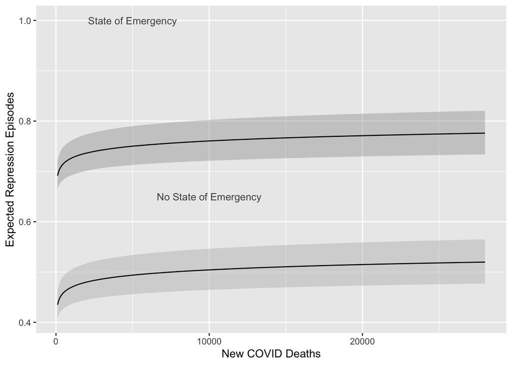

```r
predictions$deaths <- exp(predictions$deaths)

#plot
ggplot()+
  geom_ribbon(data=predictions, aes(x=deaths, ymin=lb0, ymax=ub0),fill = "grey70", alpha = .4, ) +
  geom_ribbon(data=predictions, aes(x=deaths, ymin=lb1, ymax=ub1), fill= "grey60",  alpha = .4, ) +
  geom_line(data= predictions, aes(x=deaths, y=med0))+
  geom_line(data= predictions, aes(x=deaths, y=med1))+
  labs ( colour = NULL, x = "New COVID Deaths", y =  "Expected Repression Episodes" ) +
  annotate("text", x = 5000, y = 1, label = "State of Emergency", size=3.5, colour="gray30")+
  annotate("text", x = 10000, y = .65, label = "No State of Emergency", size=3.5, colour="gray30")
```

### Discussion

$~$ $~$

That’s the primary question we’ll ask this semester.

Back to top